# BIOT Program Graduates Career Outcome

## Industry Distribution for Employed Graduates

```python
from plotly.subplots import make_subplots
import plotly.graph_objects as go
import plotly.express as px

# Filter industry distributions
employed_industry_initial = merge[merge['EmploymentStatus_Initial'] == 'Employed']['FirstIndustry'].value_counts(normalize=True)
employed_industry_3year = merge[merge['EmploymentStatus_Three_year'] == 'Employed']['Industry'].value_counts(normalize=True)

# Create side-by-side donut charts
fig = make_subplots(
    rows=1, cols=2,
    specs=[[{'type': 'domain'}, {'type': 'domain'}]],
    subplot_titles=["Initial Industry Distribution", "Three-Year Industry Distribution"]
)

# Define a qualitative color palette
industry_colors = px.colors.qualitative.Bold

# Initial industry distribution donut
fig.add_trace(go.Pie(
    labels=employed_industry_initial.index,
    values=employed_industry_initial.values,
    hole=0.5,
    textinfo='label+percent',
    textposition='inside',
    insidetextorientation='radial',
    insidetextfont=dict(size=9),
    marker_colors=industry_colors[:len(employed_industry_initial)],
    pull=[0.03] * len(employed_industry_initial)
), 1, 1)

# Three-year industry distribution donut
fig.add_trace(go.Pie(
    labels=employed_industry_3year.index,
    values=employed_industry_3year.values,
    hole=0.5,
    textinfo='label+percent',
    textposition='inside',
    insidetextorientation='radial',
    insidetextfont=dict(size=9),
    marker_colors=industry_colors[:len(employed_industry_3year)],
    pull=[0.03] * len(employed_industry_3year)
), 1, 2)

fig.update_layout(
    title=dict(
        text="<b>Industry Distribution of Employed Graduates</b>",
        x=0.5,
        xanchor='center',
        font=dict(size=18),
        y=0.98
    ),
    height=600,
    width=1000,
    showlegend=True,
    legend=dict(
        orientation="v",
        y=0.5,
        x=1.05,
        xanchor="left"
    ),
    margin=dict(t=120, b=50, l=50, r=150)
)

pio.write_image(fig, "industry_distribution.png")
```

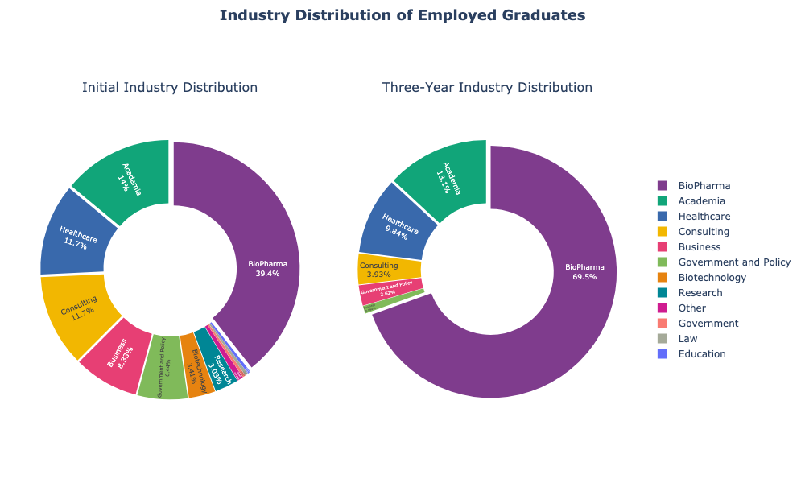

Initially, employed graduates entered a wide range of industries, with BioPharma accounting for 39.4% of roles. Three years later, BioPharma dominates at 69.5%, indicating a strong long-term alignment between graduate skillsets and the needs of that industry. This shift suggests that biotech students are ultimately landing in the field they were trained for and likely intended to enter, while early roles in sectors like Consulting and Business may serve as stepping stones or transitional paths.